# Week 5 Slides

## Count Distributions

- Consider distribution for all the samples as a ridgeline plot

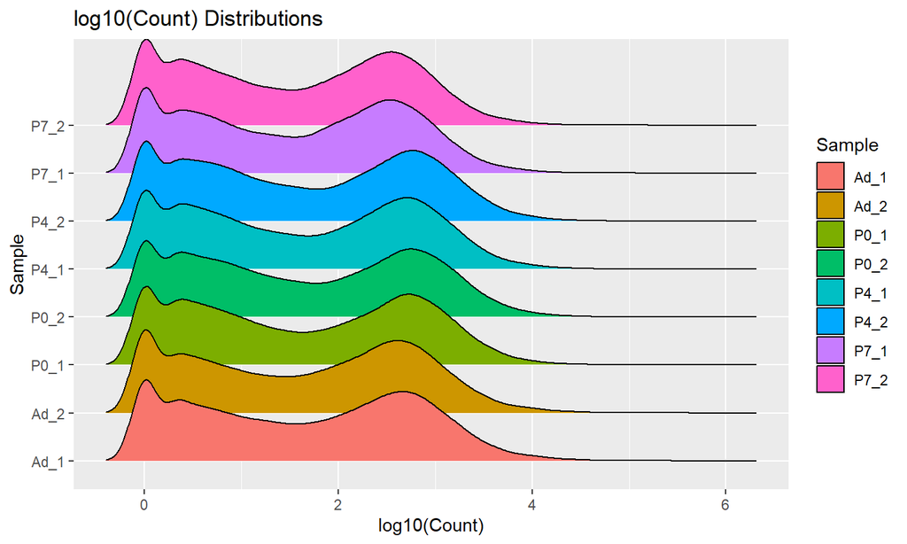

## Count Normalization

- Every sample will have a different number of reads (library size)
- The number of reads that maps to any given gene is dependent upon:
  - the relative abundance of the molecule in the sample
  - the library size of each sample
- The *raw read counts* are not directly comparable between samples
- Counts in each sample must be *normalized* so they are comparable

## Count Normalization

- Count normalization: the process by which the number of raw counts in each sample is scaled by a factor to make multiple samples comparable
- Many strategies have been proposed to do this
- The simplest is: divide ever count by some factor of the library size
  - e.g. compute *counts per million reads* or *CPM* normalization

\[ cpm_{s,i} = \frac{c_{s,i}}{l_s} * 10^6 \]

## Counts Per Million

\[ cpm_{s,i} = \frac{c_{s,i}}{l_s} * 10^6 \] * \(c_{s,i} =\) raw count of gene \(i\) in sample \(s\) * \(l_s =\) library size for sample \(s\) * In principle, the proportion of read counts for each gene will be comparable between samples

## CPM Normalization

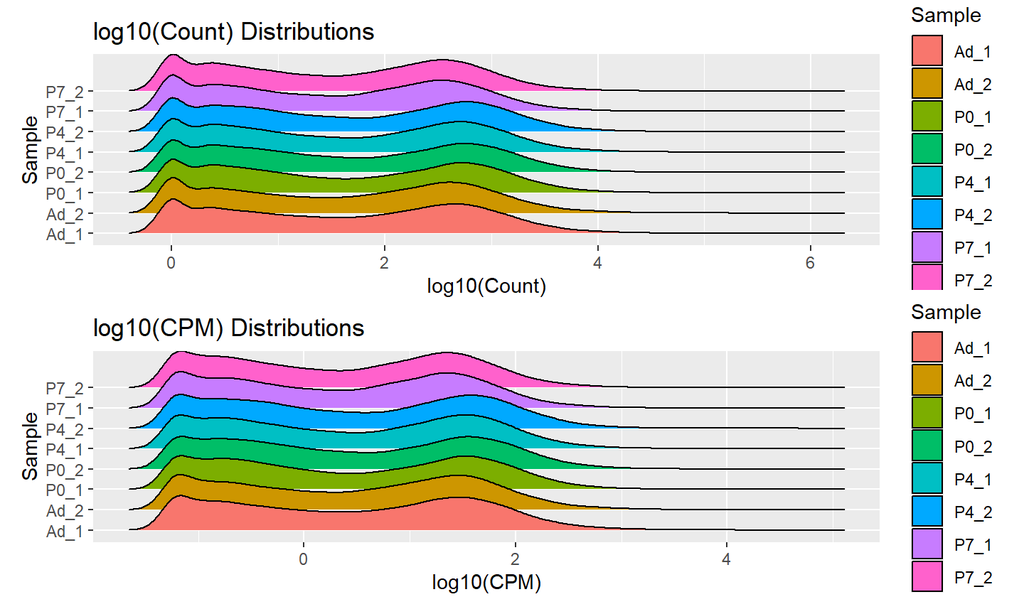

## Library Size Normalization

- CPM is a *library size normalization*
- Library size normalizations are sensitive to extreme outlier genes
  - e.g. if one gene in one sample has abnormally large counts, this can cause other gene counts to be smaller than they truly are
- These outlier counts are common in RNASeq data!
- Normalization method should be robust to these outliers

## DESeq2 Normalization

- DESeq2 bioconductor package introduced a robust normalization method
- Assumes that *most genes are not differentially expressed*
- Uses the median geometric mean computed across all samples to determine the scale factor for each sample
- Currently the *de facto* standard normalization method for well characterized genomes

## DESeq2 Normalization

```r
library(DESeq2)
# DESeq2 requires a counts matrix
# column data (sample information), and a formula
# the counts matrix *must be raw counts*
count_mat <- as.matrix(filtered_counts[-1])

row.names(count_mat) <- filtered_counts$gene

dds <- DESeqDataSetFromMatrix(
  countData=count_mat,
  colData=tibble(sample_name=colnames(filtered_counts[-1])),
  design=~1 # no formula needed, ~1 produces a trivial design matrix
)
```

## DESeq2 Normalization

```r
# compute normalization factors
dds <- estimateSizeFactors(dds)

# extract the normalized counts
deseq_norm_counts <- as_tibble(counts(dds,normalized=TRUE)) %>%
  mutate(gene=filtered_counts$gene) %>%
  relocate(gene) # relocate changes column order
```

## DESeq2 vs CPM

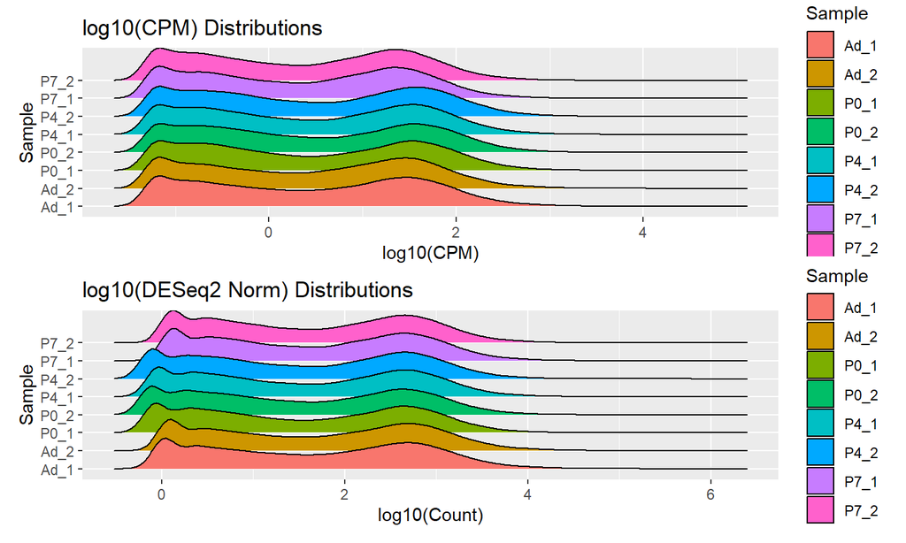

## DESeq2 Considerations

The DESeq2 normalization procedure has two important considerations:

- **The procedure borrows information across all samples.**
- **The procedure does not use genes with any zero counts.**

The CPM normalization procedure does not borrow information across all samples, and therefore is not subject to these considerations.

## Count Transformation

- One way to deal with the non-normality of count data is transform it to follow a normal distribution
- Enables more statistical methods like linear regression to be used
- Count data are roughly *log-normal*, however low and zero counts can be problematic for traditional `log()`
- The DESeq2 package provides the `rlog()` function that performs a regularized logarithmic transformation that avoids these biases

```r
# the dds is the DESeq2 object from earlier
rld <- rlog(dds)
```

## Count Transformation

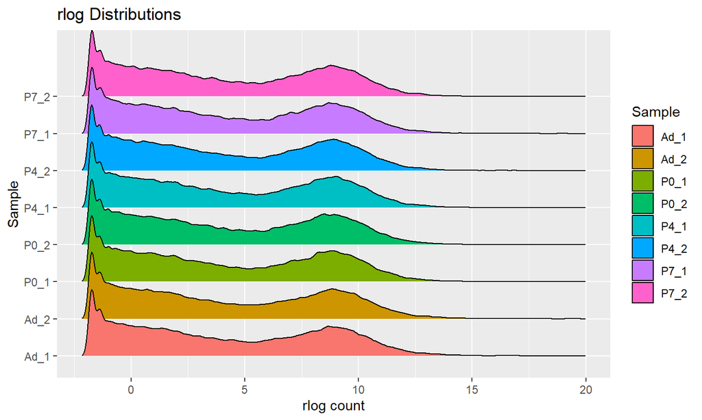